# Debugging and Testing

Statistical Computing, 36-350

Tuesday November 15, 2022

# Last week: Modeling

- Fitting models is critical to both statistical inference and prediction
- Exploratory data analysis is a very good first step and gives you a sense of what you’re dealing with before you start modeling
- Linear regression is the most basic modeling tool of all, and one of the most ubiquitous
- `lm()` allows you to fit a linear model by specifying a formula, in terms of column names of a given data frame
- Utility functions `coef()`, `fitted()`, `residuals()`, `summary()`, `plot()`, `predict()` are very handy and should be used over manual access tricks
- Logistic regression is the natural extension of linear regression to binary data; use `glm()` with `family="binomial"` and all the same utility functions
- Generalized additive models add a level of flexibility in that they allow the predictors to have nonlinear effects; use `gam()` and utility functions

# Part I

*Debugging basics*

# Bug!

The original name for glitches and unexpected defects: dates back to at least Edison in 1876, but better story from Grace Hopper in 1947:

[figure not shown]

(From Wikipedia)

# Debugging: what and why?

Debugging is a the process of locating, understanding, and removing bugs from your code

Why should we care to learn about this?

- The truth: you’re going to have to debug, because you’re not perfect (none of us are!) and can’t write perfect code
- Debugging is frustrating and time-consuming, but essential
- Writing code that makes it easier to debug later is worth it, even if it takes a bit more time (lots of our design ideas support this)
- Simple things you can do to help: use lots of comments, use meaningful variable names!

# Debugging: how?

Debugging is (largely) a process of differential diagnosis. Stages of debugging:

0. Reproduce the error: can you make the bug reappear?
1. Characterize the error: what can you see that is going wrong?
2. Localize the error: where in the code does the mistake originate?
3. Modify the code: did you eliminate the error? Did you add new ones?

# Reproduce the bug

Step 0: make if happen again

- Can we produce it repeatedly when re-running the same code, with the same input values?
- And if we run the same code in a clean copy of R, does the same thing happen?

# Characterize the bug

Step 1: figure out if it’s a pervasive/big problem

- How much can we change the inputs and get the same error?
- Or is it a different error?
- And how big is the error?

# Localize the bug

Step 2: find out exactly where things are going wrong

- This is most often the hardest part!
- Understand errors, using `traceback()`, and also `cat()`, `print()`
- Interactively debug with the R tool `browser()`

# Localizing can be easy or hard

Sometimes error messages are easier to decode, sometimes they’re harder; this can make locating the bug easier or harder

```r
my.plotter = function(x, y, my.list=NULL) {
  if (!is.null(my.list))
    plot(my.list, main="A plot from my.list!")
  else
    plot(x, y, main="A plot from x, y!")
}
```

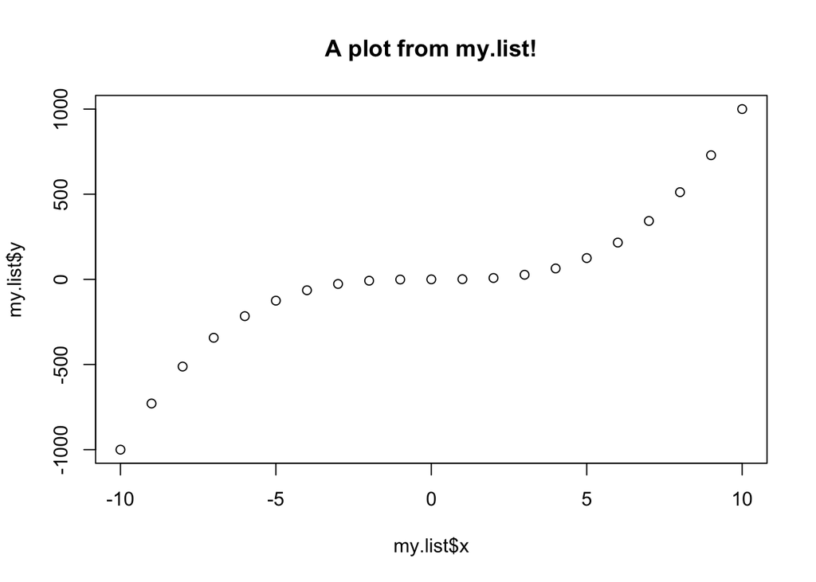

```r
my.plotter(my.list=list(x=-10:10, y=(-10:10)^3))
```

```r
my.plotter() # Easy to understand error message
```

```
## Error in plot(x, y, main = "A plot from x, y!"): argument "x" is missing, with no default
```

```r
my.plotter(my.list=list(x=-10:10, Y=(-10:10)^3)) # Not as clear
```

```
## Error in xy.coords(x, y, xlabel, ylabel, log): 'x' is a list, but does not have components 'x' and 'y'
```

Who called `xy.coords()`? (Not us, at least not explicitly!) And why is it saying ‘x’ is a list? (We never set it to be so!)

# `traceback()`

Calling `traceback()`, after an error: traces back through all the function calls leading to the error

- Start your attention at the “bottom”, where you recognize the function you called
- Read your way up to the “top”, which is the lowest-level function that produces the error
- Often the most useful bit is somewhere in the middle

If you run `my.plotter(my.list=list(x=-10:10, Y=(-10:10)^3))` in the console, then call `traceback()`, you’ll see:

```
> traceback()
5: stop("'x' is a list, but does not have components 'x' and 'y'")
4: xy.coords(x, y, xlabel, ylabel, log)
3: plot.default(my.list, main = "A plot from my.list!")
2: plot(my.list, main = "A plot from my.list!") at #2
1: my.plotter(my.list = list(x = -10:10, Y = (-10:10)^3))
```

We can see that `my.plotter()` is calling `plot()` is calling `plot.default()` is calling `xy.coords()`, and this last function is throwing the error

Why? Its first argument `x` is being set to `my.list`, which is OK, but then it’s expecting this list to have components named `x` and `y` (ours are named `x` and `Y`)

# Part II

*Debugging tools*

# `cat()`, `print()`

Most primitive strategy: manually call `cat()` or `print()` at various points, to print out the state of variables, to help you localize the error

This is the “stone knives and bear skins” approach to debugging; it is still very popular among some people (actual quote from stackoverflow):

> I’ve been a software developer for over twenty years … I’ve never had a problem I could not debug using some careful thought, and well-placed debugging print statements. Many people say that my techniques are primitive, and using a real debugger in an IDE is much better. Yet from my observation, IDE users don’t appear to debug faster or more successfully than I can, using my stone knives and bear skins.

# Specialized tools for debugging

R provides you with many debugging tools. Why should we use them, and move past our handy `cat()` or `print()` statements?

Let’s see what our primitive hunter found on stackoverflow, after a receiving bunch of suggestions in response to his quote:

> Sweet! … Very illuminating. Debuggers can help me do ad hoc inspection or alteration of variables, code, or any other aspect of the runtime environment, whereas manual debugging requires me to stop, edit, and re-execute.

# `browser()`

One of the simplest but most powerful built-in debugging tools: `browser()`. Place a call to `browser()` at any point in your function that you want to debug. As in:

```
my.fun = function(arg1, arg2, arg3) {
  # Some initial code
  browser()
  # Some final code
}
```

Then redefine the function in the console, and run it. Once execution gets to the line with `browser()`, you’ll enter an interactive debug mode

# Things to do while browsing

While in the interactive debug mode granted to you by `browser()`, you can type any normal R code into the console, to be executed within in the function environment, so you can, e.g., investigate the values of variables defined in the function

You can also type:

- “n” (or simply return) to execute the next command
- “s” to step into the next function
- “f” to finish the current loop or function
- “c” to continue execution normally
- “Q” to stop the function and return to the console

(To print any variables named `n`, `s`, `f`, `c`, or `Q`, defined in the function environment, use `print(n)`, `print(s)`, etc.)

# Browsing in R Studio

You have buttons to click that do the same thing as “n”, “s”, “f”, “c”, “Q” in the “Console” panel; you can see the locally defined variables in the “Environment” panel; the traceback in the “Traceback” panel

[figure not shown]

# Knitting and debugging

As with `cat()`, `print()`, `traceback()`, used for debugging, you should only run `browser()` in the console, never in an Rmd code chunk that is supposed to be evaluated when knitting

But, to keep track of your debugging code (that you’ll run in the console), you can still use code chunks in Rmd, you just have to specify `eval=FALSE`

```r
# As an example, here's a code chunk that we can keep around in this Rmd doc,
# but that will never be evaluated (because eval=FALSE) in the Rmd file, take
# a look at it!
big.mat = matrix(rnorm(1000)^3, 1000, 1000)
big.mat
# Note that the output of big.mat is not printed to the console, and also
# that big.mat was never actually created! (This code was not evaluated)
```

# Part III

*Testing*

# What is testing?

Testing is the systematic writing of additional code to ensure your functions behave properly. We’ll focus on two aspects

- **Assertions**: checking your function is being passed in proper inputs
- **Unit tests**: checking your function does the right thing in basic cases

Benefits of testing:

- Enables you to catch problems early (easier debugging)
- Provides natural documentation of your functions
- Encourages you to write simpler functions via refactoring

Of course, this requires you to spend more time upfront, but it is often worth it (saves time spent debugging later)

# Assertions

Assertions are checks to ensure that the inputs to your function are properly formatted

- For example, if your function expects a matrix, then we first check that it is actually a matrix (and not a vector, say)
- Otherwise your function could be acting on unexpected input types, and bugs could arise that are hard to interpret/locate
- So an assertion stops the execution of the function as soon as it encounters an unexpected input

```r
# Function to create n x n matrix of 0s
create.matrix.simple = function(n){
  matrix(0, n, n)
}

# Not meaningful errors!
create.matrix.simple(4)
```

```
##      [,1] [,2] [,3] [,4]
## [1,]    0    0    0    0
## [2,]    0    0    0    0
## [3,]    0    0    0    0
## [4,]    0    0    0    0
```

```r
create.matrix.simple(4.1)
```

```
##      [,1] [,2] [,3] [,4]
## [1,]    0    0    0    0
## [2,]    0    0    0    0
## [3,]    0    0    0    0
## [4,]    0    0    0    0
```

```r
create.matrix.simple("asdf")
```

```
## Error in matrix(0, n, n): non-numeric matrix extent
```

# `assert_that()`

We’ll be using `assert_that()` function in the `assertthat` package to make assertions: allows us to write custom, meaningful error messages

```r
library(assertthat)

create.matrix = function(n){
  assert_that(length(n) == 1 && is.numeric(n) &&
                n > 0 && n %% 1 == 0,
              msg="n is not a positive integer")
  matrix(0, n, n)
}

# Errors are now meaningful
create.matrix(4)
```

```
##      [,1] [,2] [,3] [,4]
## [1,]    0    0    0    0
## [2,]    0    0    0    0
## [3,]    0    0    0    0
## [4,]    0    0    0    0
```

```r
create.matrix(4.1)
```

```
## Error: n is not a positive integer
```

```r
create.matrix("asdf")
```

```
## Error: n is not a positive integer
```

# Another example

```r
# Function that performs linear regression
run.lm.simple = function(dat){
  res = lm(X1 ~ ., data = dat)
  coef(res)
}

mat = matrix(rnorm(20), 10, 2)
colnames(mat) = paste0("X", 1:2)
dat = as.data.frame(mat)

# Not meaningful errors
run.lm.simple(dat)
```

```
## (Intercept)          X2
##  0.09957273  0.21538540
```

```r
run.lm.simple(mat)
```

```
## Error in model.frame.default(formula = X1 ~ ., data = dat, drop.unused.levels = TRUE): 'data' must be a data.frame, not a matrix or an array
```

```r
# Meaningful errors
run.lm = function(dat){
  assert_that(is.data.frame(dat),
              msg="dat must be a data frame")
  res = lm(X1 ~ ., data = dat)
  coef(res)
}

run.lm(dat)
```

```
## (Intercept)          X2
##  0.09957273  0.21538540
```

```r
run.lm(mat)
```

```
## Error: dat must be a data frame
```

# Unit tests

Unit tests are used to check that your code passes basic sanity checks at various stages of development. We’ll be using `test_that()` function in the `testthat` package to do unit tests: you’ll learn the details in lab

Some high-level tips:

- Always run your unit tests whenever you change your function
- Also always run unit tests before expensive computations
- When you encounter a bug during your code development, add an appropriate unit test
- Write short functions. It’s hard to write a unit test for a 100+ line function

# Summary

- Debugging involves diagnosing your code when you encounter an error or unexpected behavior
  - Step 0: Reproduce the error
  - Step 1: Characterize the error
  - Step 2: Localize the error
  - Step 3: Modify the code
- `traceback()`, `cat()`, `print()`: manual debugging tools
- `browser()`: interactive debugging tool
- Testing involves writing additional code to ensure your functions behave as expected
- Compared to debugging, it is proactive, rather than reactive
- `assert_that()`, `test_that()`: tools for assertions and unit tests
- **Important**: it’s hard to teach good coding practices. The best way to learn is to implement these yourself from now onwards!